# Homework 2

Ahmet Pala

25 October 2018

#### Task 1.a

In this part, bet-at-home, bwin, youwin, bet365 and Tipico was selected as 5 bookmakers to analyze their odds. First of all, their odds for different odd types were combined in a particular data. Final odds of each bookmaker were taken into consideration.Then the combined odd data was merged with the matches’ data. After all, PCA were implemented on this combined data.

```
## Importance of components:
##                           Comp.1    Comp.2    Comp.3     Comp.4     Comp.5
## Standard deviation     5.1341796 3.7628618 3.1103537 1.10432277 0.94174887
## Proportion of Variance 0.4544793 0.2441229 0.1667983 0.02102636 0.01529122
## Cumulative Proportion  0.4544793 0.6986022 0.8654005 0.88642686 0.90171808
##                            Comp.6     Comp.7      Comp.8      Comp.9
## Standard deviation     0.87594124 0.80213255 0.653800947 0.604353124
## Proportion of Variance 0.01322885 0.01109339 0.007369925 0.006297288
## Cumulative Proportion  0.91494693 0.92604032 0.933410244 0.939707532
##                            Comp.10     Comp.11     Comp.12     Comp.13
## Standard deviation     0.572105042 0.537166541 0.523487191 0.493462221
## Proportion of Variance 0.005643175 0.004974964 0.004724808 0.004198361
## Cumulative Proportion  0.945350708 0.950325671 0.955050479 0.959248840
##                            Comp.14     Comp.15     Comp.16     Comp.17
## Standard deviation     0.480783883 0.453198162 0.440492467 0.436421465
## Proportion of Variance 0.003985399 0.003541182 0.003345407 0.003283857
## Cumulative Proportion  0.963234239 0.966775422 0.970120829 0.973404686
##                            Comp.18     Comp.19     Comp.20     Comp.21
## Standard deviation     0.401806285 0.373477708 0.364684832 0.333928208
## Proportion of Variance 0.002783591 0.002404924 0.002293018 0.001922553
## Cumulative Proportion  0.976188277 0.978593201 0.980886219 0.982808771
##                            Comp.22     Comp.23     Comp.24     Comp.25
## Standard deviation     0.320197994 0.296576197 0.278423745 0.260470414
## Proportion of Variance 0.001767703 0.001516508 0.001336548 0.001169739
## Cumulative Proportion  0.984576474 0.986092981 0.987429529 0.988599268
##                            Comp.26     Comp.27      Comp.28     Comp.29
## Standard deviation     0.247460665 0.236493854 0.2208614220 0.216647799
## Proportion of Variance 0.001055807 0.000964299 0.0008410305 0.000809246
## Cumulative Proportion  0.989655075 0.990619374 0.9914604041 0.992269650
##                            Comp.30      Comp.31      Comp.32      Comp.33
## Standard deviation     0.201863384 0.1928625078 0.1782209375 0.1763273222
## Proportion of Variance 0.000702566 0.0006413094 0.0005476328 0.0005360573
## Cumulative Proportion  0.992972216 0.9936135255 0.9941611583 0.9946972156
##                             Comp.34      Comp.35      Comp.36      Comp.37
## Standard deviation     0.1676779251 0.1584041493 0.1498679310 0.1474452264
## Proportion of Variance 0.0004847567 0.0004326185 0.0003872482 0.0003748292
## Cumulative Proportion  0.9951819723 0.9956145908 0.9960018390 0.9963766682
##                             Comp.38      Comp.39      Comp.40      Comp.41
## Standard deviation     0.1391839778 0.1340162411 0.1291050970 0.1246447109
## Proportion of Variance 0.0003340031 0.0003096613 0.0002873815 0.0002678673
## Cumulative Proportion  0.9967106713 0.9970203326 0.9973077141 0.9975755814
##                             Comp.42      Comp.43      Comp.44      Comp.45
## Standard deviation     0.1221695656 0.1177824309 0.1131156022 0.1081459872
## Proportion of Variance 0.0002573345 0.0002391845 0.0002206059 0.0002016475
## Cumulative Proportion  0.9978329159 0.9980721004 0.9982927063 0.9984943537
##                             Comp.46     Comp.47      Comp.48     Comp.49
## Standard deviation     0.1078220652 0.101898639 0.0975817412 0.095045038
## Proportion of Variance 0.0002004413 0.000179023 0.0001641758 0.000155751
## Cumulative Proportion  0.9986947951 0.998873818 0.9990379939 0.999193745
##                             Comp.50      Comp.51      Comp.52      Comp.53
## Standard deviation     0.0919409002 0.0894788013 0.0842211804 7.477325e-02
## Proportion of Variance 0.0001457436 0.0001380423 0.0001222967 9.639722e-05
## Cumulative Proportion  0.9993394885 0.9994775308 0.9995998275 9.996962e-01
##                             Comp.54      Comp.55      Comp.56      Comp.57
## Standard deviation     7.027966e-02 6.803244e-02 5.625084e-02 5.249035e-02
## Proportion of Variance 8.515914e-05 7.980022e-05 5.455443e-05 4.750409e-05
## Cumulative Proportion  9.997814e-01 9.998612e-01 9.999157e-01 9.999632e-01
##                             Comp.58
## Standard deviation     0.0461728188
## Proportion of Variance 0.0000367574
## Cumulative Proportion  1.0000000000
```

*Figure 1a: Importance of Components in PCA for IsOver*

As it can be seen from figure 1a, first 3 components can explain nearly the whole variation (87% of the total variation), and if we consider cumulatively, adding other components changes the total amount of variation less compared to the first three of them.

```
##
## Loadings:
##                   Comp.1 Comp.2 Comp.3 Comp.4 Comp.5 Comp.6 Comp.7 Comp.8
## 1_Tipico                  0.212  0.109         0.119
## 1_bet365                  0.216  0.108
## 1_bwin                    0.167                       0.530 -0.246 -0.187
## 1_youwin                  0.169        -0.176 -0.153 -0.395        -0.489
## 12_Tipico          0.137 -0.119        -0.338  0.110  0.157  0.317
## 12_bet-at-home     0.148 -0.115        -0.173         0.120  0.112  0.207
## 12_bet365          0.158 -0.126        -0.173
## 12_bwin            0.157 -0.127        -0.140                       0.100
## 12_youwin          0.133 -0.121        -0.350 -0.228        -0.122  0.268
## 1X_Tipico                 0.209
## 1X_bet-at-home            0.211
## 1X_bet365                 0.213
## 1X_bwin                   0.213
## 1X_youwin                 0.204                             -0.146 -0.144
## 2_Tipico          -0.177                      -0.136 -0.101 -0.207  0.141
## 2_bet365          -0.187
## 2_bwin            -0.143                       0.339 -0.554         0.173
## 2_youwin          -0.144                0.339  0.381  0.249         0.158
## NO_Tipico                       -0.271         0.152               -0.187
## NO_bet-at-home                  -0.275
## NO_bet365                       -0.282
## NO_bwin                         -0.274
## NO_youwin                       -0.266                      -0.270
## X2_Tipico         -0.166                0.259 -0.106        -0.316  0.109
## X2_bet-at-home    -0.182
## X2_bet365         -0.187
## X2_bwin           -0.188
## X2_youwin         -0.159                0.251  0.351         0.195
## YES_Tipico                       0.266        -0.181                0.223
## YES_bet-at-home                  0.273                       0.121
## YES_bet365                       0.276                       0.120
## YES_bwin                         0.271
## YES_youwin                       0.261                       0.288
## odd1_Tipico               0.202  0.105         0.107
## odd1_bet-at-home          0.206  0.105                              0.164
## odd1_bet365               0.207  0.107         0.102                0.173
## odd1_bwin                 0.206  0.105                              0.142
```

[output cut: 515 more lines]

```
## SS loadings      1.000   1.000   1.000   1.000   1.000   1.000   1.000
## Proportion Var   0.017   0.017   0.017   0.017   0.017   0.017   0.017
## Cumulative Var   0.638   0.655   0.672   0.690   0.707   0.724   0.741
##                Comp.44 Comp.45 Comp.46 Comp.47 Comp.48 Comp.49 Comp.50
## SS loadings      1.000   1.000   1.000   1.000   1.000   1.000   1.000
## Proportion Var   0.017   0.017   0.017   0.017   0.017   0.017   0.017
## Cumulative Var   0.759   0.776   0.793   0.810   0.828   0.845   0.862
##                Comp.51 Comp.52 Comp.53 Comp.54 Comp.55 Comp.56 Comp.57
## SS loadings      1.000   1.000   1.000   1.000   1.000   1.000   1.000
## Proportion Var   0.017   0.017   0.017   0.017   0.017   0.017   0.017
## Cumulative Var   0.879   0.897   0.914   0.931   0.948   0.966   0.983
##                Comp.58
## SS loadings      1.000
## Proportion Var   0.017
## Cumulative Var   1.000
```

*Figure 1b: Loadings(Eigenvectors) in PCA for IsOver*

Here, the importance of each vector (i.e. odds of bookmakers) can be interpretted since it is known that the most important components are the first one (because it explains the 45% of the variation). Then it can be said that the x2 odd type for bwin and x2 odd type for bet365 are seem to be most important features since they contribute to the variation much compared to other features composing the data.

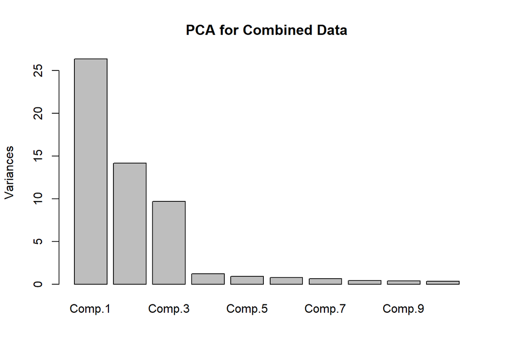

*Figure 2a: PCA for Combined Data*

As mentioned before by observing the importance of the components, the most crucial components are component 1, component 2 and component 3 since they can form the huge part of the variation. It will be useful for a predictor to use first three components to explain the model if there is a restriction about the number of components to be used.

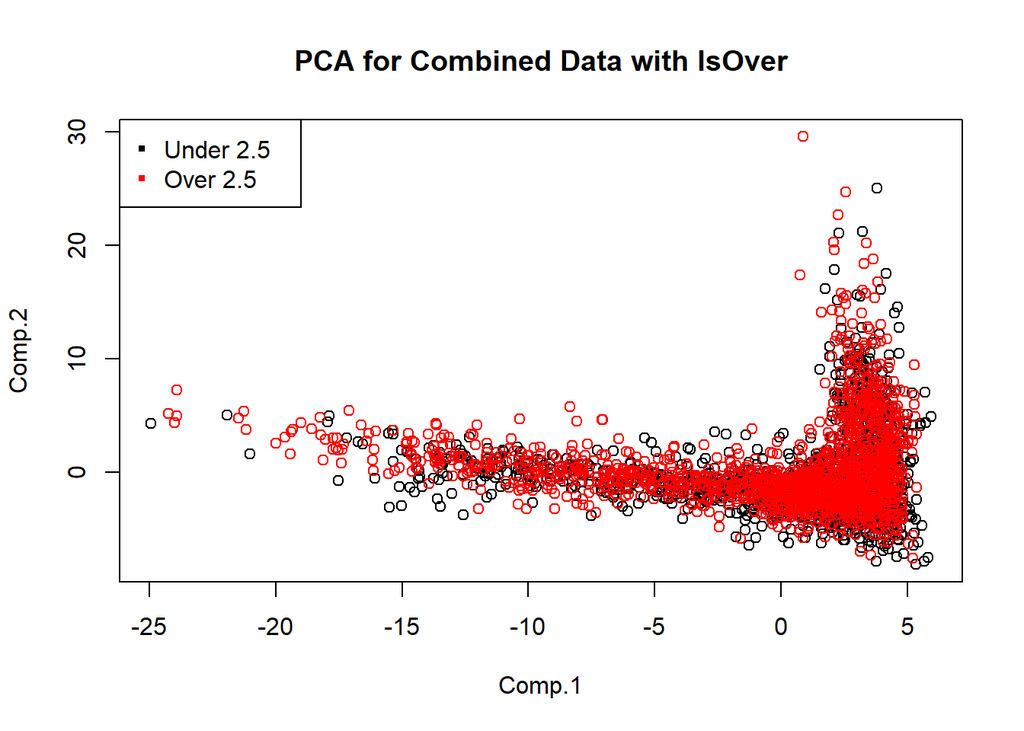

*Figure 2b: PCA for Combined Data with IsOver*

In order to see the relationship between match results (over 2.5 or under 2.5) with the odds of different bookmakers (5 of them) PCA analysis was applied and the first two components were plotted. As it can be seen from the figure, matches finished over 2.5 are shown with red points while the matches resulted under 2.5 are shown with black ones. According to the graph, it can be confidently said that the points are not linearly seperabe (black and red points), which means that whether the matches will result over 2.5 (or under 2.5) cannot be explained clearly by the odds data. However, this plot is in two dimension and first two components were used. The first two components explain the 70% of the total variation. It may be useful to see the plot first 26 components (they explain the 99% of the variation), which requires 26 dimensions and it is not realistic to plot such a graph.

## Task 1.b

```
##        V1                V2
##  Min.   :-54.846   Min.   :-2.956
##  1st Qu.: -2.306   1st Qu.:-2.403
##  Median :  2.935   Median :-1.678
##  Mean   :  0.000   Mean   : 0.000
##  3rd Qu.:  5.970   3rd Qu.: 1.030
##  Max.   : 16.519   Max.   :37.259
```

*Figure 3: Summary of MDS (Euclidean Distance)*

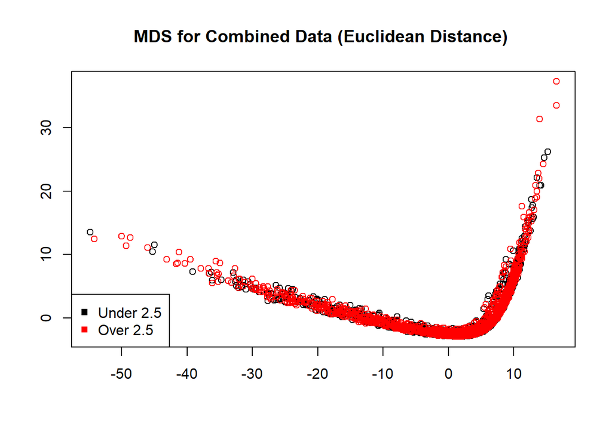

*Figure 4: MDS for Combined Data (Euclidean Distance)*

```
##        V1                 V2
##  Min.   :-212.889   Min.   :-27.927
##  1st Qu.: -14.155   1st Qu.:-10.229
##  Median :   8.876   Median : -4.534
##  Mean   :   0.000   Mean   :  0.000
##  3rd Qu.:  25.057   3rd Qu.:  7.685
##  Max.   : 112.362   Max.   :128.942
```

*Figure 5: Summary of MDS (Manhattan Distance)*

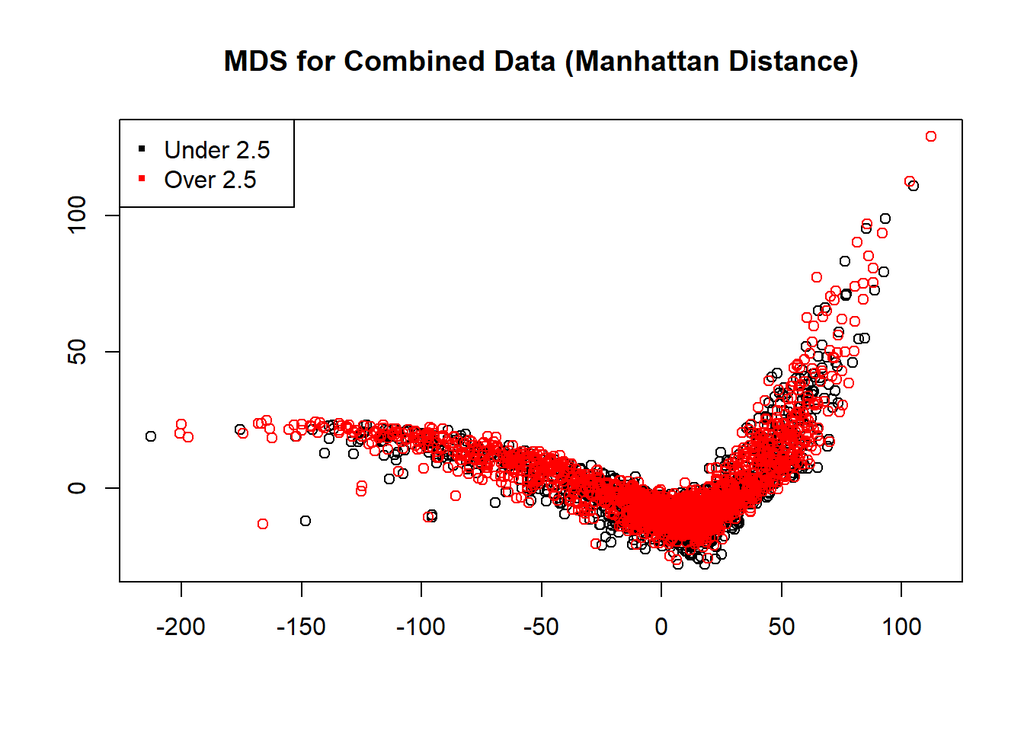

*Figure 6: MDS for Combined Data (Manhattan Distance)*

## Task 2

In this part, the data used in Task 1.a was utilized in order to apply PCA for match result (Home win, Away win or Tie). In order to check the winner team (or there is no winner, i.e. Tie), Match_Outcome column was created and it takes 0 with Tie, 1 with Home win, 2 with Away win.

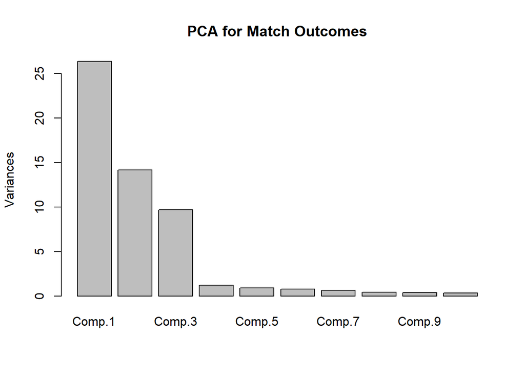

*Figure 7: PCA for Combined Data*

Since the data used in part 1.a is again utilized here, principal component analysis gives us the same results. Therefore, importance of the components and the eigenvectors can be examined from figure 1a and figure 1b. In figure 7, PCA was plotted again, and it is obvious that the first 3 components are the most important ones since they explain most of the variation.

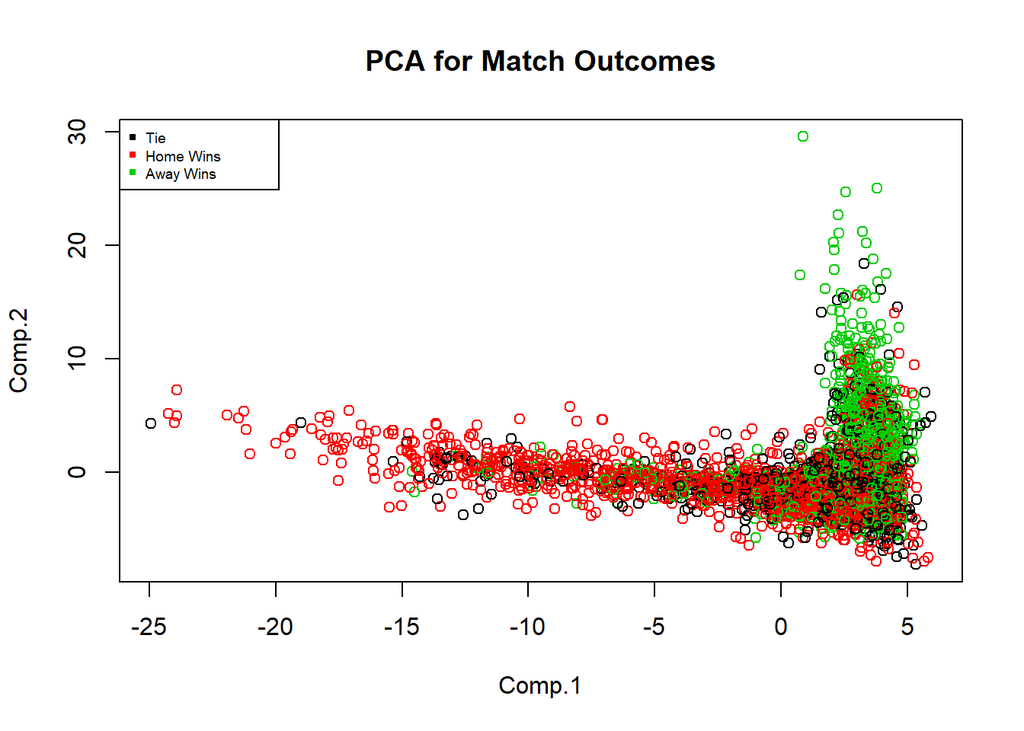

*Figure 8: PCA for Match Results (Homewin / Awaywin / Tie)*

After implementing PCA, scores were plotted (Figure 8). Here, the first two components again were plotted since they explain the huge amount of variation. The distribution of the points is identical with the PCA plot for IsOVer; however, what is interested here is the match result (Homewin/Awaywin/Tie). For this purpose, different match results are shown with different colors as it can be seen from the figure 8. It is obvious that, the points representing different match results seem to be more linearly seperable compared to the PCA for IsOver, which means that the odds of bookmakers give better information about the match result(Home/Away/Tie) than the match result as over or under 2.5. Here, home wins seem to be at the lefthandside on the graph, while the awaywins are at the righthandside and the topright on the graph in general.

## Task 3

In this part, certain operations were implemented on an image with the extension of jpeg. First of all, I install an image (.jpeg) of my little cousin, Ayaz, into R by using the particular package of R “jpeg”. This photo can be seen in figure 10. Since the operations take too long, the image was converted into 200x200 px (pixel) before the installation into the R.

#### 2

The image consists of 200 rows 200 columns and 3 components which represent the red, green or blue color itself. In each channel,there are numeric values between 0 and 1 which show the intensity level of the corresponding rgb channel. The dimension of the image is 200 200 3. The structure and the dimension of the image can be seen from the figure 9.

```
##  num [1:200, 1:200, 1:3] 0.263 0.388 0.278 0.361 0.286 ...
```

```
## [1] 200 200   3
```

*Figure 9: The structure and dimension of the image - original photo*

#### 2.a

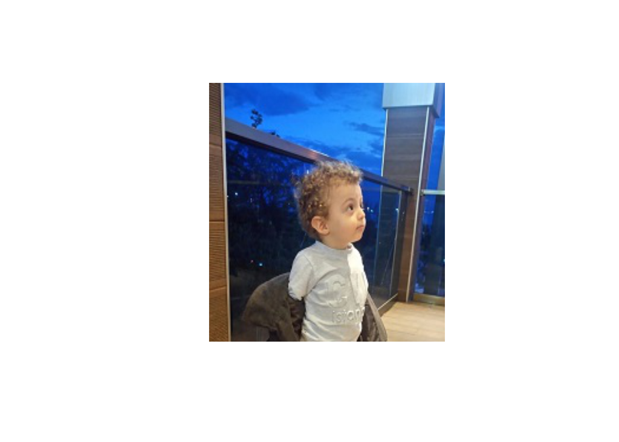

*Figure 10: The image to be used on certain operations - Original photo*

#### 2.b

After checking dimension and the structure of image, each channel of the image were displayed using image function.

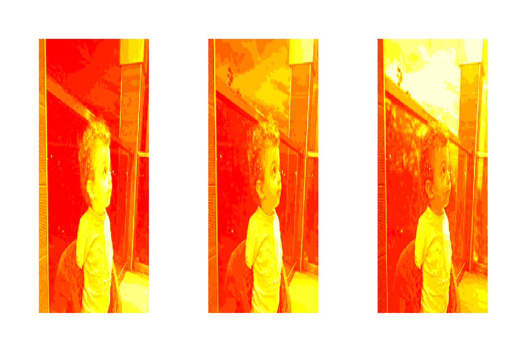

*Figure 11: Channels of the original photo (Channel 1,2 and 3 on the plot respectively)*

#### 3.a

In this part, in order to create a noisy image, a random noise from uniform distribution between 0 and 0.1 was added to each pixel value for each channel of original image. However, adding noise sometimes lead to values become more than one. As mentioned before, in each channel, numeric values have to be between 0 and 1. In this case, the values above 1 after addig noise, accepted as 1. This was achieved by two for loop which can be seen from the Appendix part.

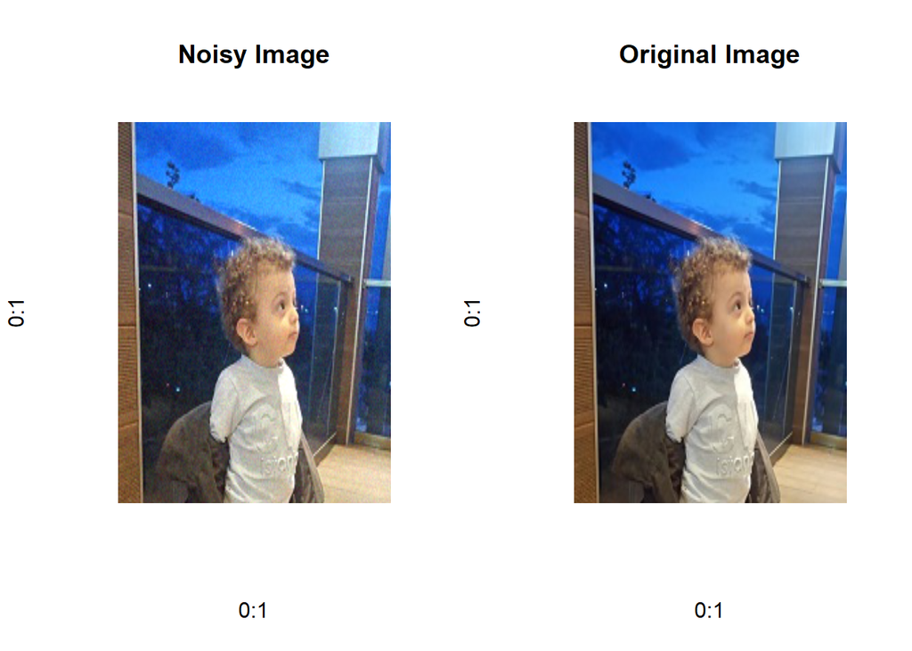

*Figure 12: Noisy and original image on a single plot*

#### 3.b

After obtaining the noisy image which has a lower display quality, its all channels (3 channels) were plotted on a single graph.

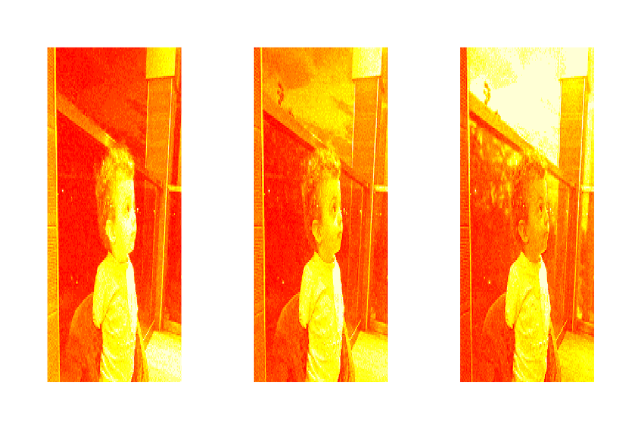

*Figure 13: Noisy image’s Channel 1,2 and 3, respectively on the graph*

#### 4

In this part,the noisy image was converted into a grayscale one so that we can apply PCA. The noisy image has dimension of 200 200 3. 3 represents the red, green and blue chaannels. By converting this into grayscale one, its dimension will be 200 200. We reduce the color channels and our new image will only have the shades of gray.

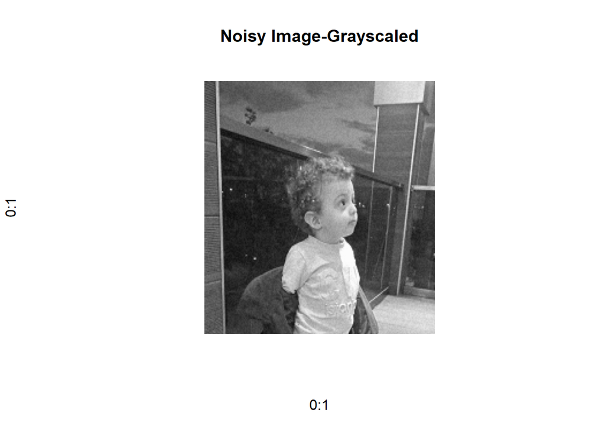

*Figure 14: Grayscale version of the noisy image*

#### 4.a

A grayscale image can be considered as a 2D signal. In this part, the aim is to apply PCA to patches extracted from the grayscale noisy image. First of all, patches were extracted from the image. After obtaining the patches, PCA analysis was applied to this data matrix.

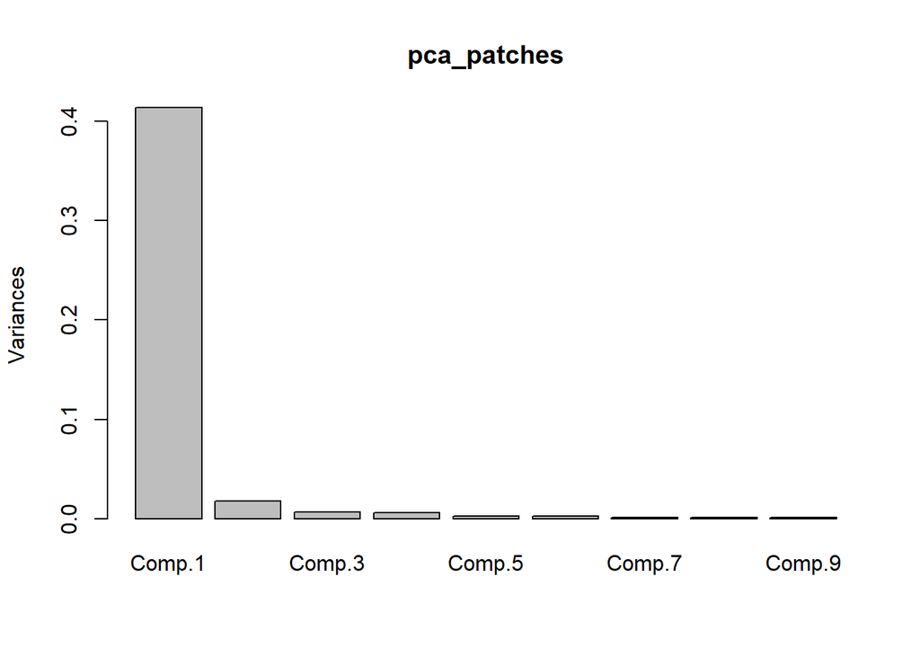

*Figure 15: PCA results of the patches extracted from the image*

```
## Importance of components:
##                           Comp.1     Comp.2     Comp.3     Comp.4
## Standard deviation     0.6434105 0.13250459 0.08275216 0.07801937
## Proportion of Variance 0.9139600 0.03876259 0.01511853 0.01343866
## Cumulative Proportion  0.9139600 0.95272261 0.96784114 0.98127980
##                             Comp.5      Comp.6      Comp.7      Comp.8
## Standard deviation     0.050315697 0.047468936 0.037439686 0.037168673
## Proportion of Variance 0.005589306 0.004974735 0.003094677 0.003050037
## Cumulative Proportion  0.986869103 0.991843837 0.994938514 0.997988551
##                             Comp.9
## Standard deviation     0.030184157
## Proportion of Variance 0.002011449
## Cumulative Proportion  1.000000000
```

*Figure 16: Importance of components*

```
##
## Loadings:
##       Comp.1 Comp.2 Comp.3 Comp.4 Comp.5 Comp.6 Comp.7 Comp.8 Comp.9
##  [1,]  0.329  0.393  0.395  0.275  0.195  0.492         0.432  0.197
##  [2,]  0.336         0.448 -0.449 -0.171  0.226  0.331 -0.438 -0.321
##  [3,]  0.330 -0.409  0.380  0.201 -0.515 -0.208 -0.432         0.204
##  [4,]  0.332  0.421         0.245  0.293 -0.327 -0.446 -0.348 -0.373
##  [5,]  0.340               -0.494  0.400 -0.356                0.595
##  [6,]  0.334 -0.421         0.242  0.285 -0.321  0.449  0.351 -0.379
##  [7,]  0.330  0.410 -0.378  0.198 -0.520 -0.205  0.432         0.199
##  [8,]  0.338        -0.441 -0.457 -0.175  0.219 -0.339  0.433 -0.318
##  [9,]  0.332 -0.394 -0.402  0.268  0.198  0.487        -0.430  0.199
##
##                Comp.1 Comp.2 Comp.3 Comp.4 Comp.5 Comp.6 Comp.7 Comp.8
## SS loadings     1.000  1.000  1.000  1.000  1.000  1.000  1.000  1.000
## Proportion Var  0.111  0.111  0.111  0.111  0.111  0.111  0.111  0.111
## Cumulative Var  0.111  0.222  0.333  0.444  0.556  0.667  0.778  0.889
##                Comp.9
## SS loadings     1.000
## Proportion Var  0.111
## Cumulative Var  1.000
```

*Figure 17: Loadings (Eigenvectors)*

After implementing PCA to the patches, it can be said that the most important component is the first one. it can explain huge amount of variance itself (91% of the total variance). Since the first component can explain nearly the total variation and the loadings of the component 1 are close to each other, tle plot of this component (scores) will give a very reasonable image.

#### 4.b

In this part, the first, second and third component was used seperately to reconstruct the image. After these three components were used for patches, the scores (recall that each patch is extracted from a certain location so that you can obtain an image from the scores). of these three components were plotted on a single plot after scaling (since the values must be between 0 and 1 as mentioned before) as can be seen from the figure 18.

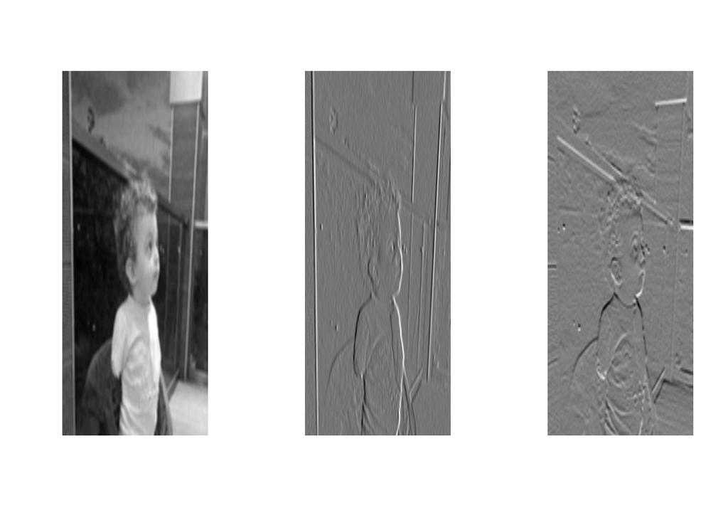

*Figure 18: Images constructed by the scores of Component 1,2 and 3, respectively on the figure*

#### 4.c

Components (eigenvectors) themselves refers to a patch. Therefore, if we transform the components into a matrix form, we can obtain an image. In this part the component 1,2 and 3 were transformed into 3 by 3 matrices. Then they were scaled to the interval from 0 to 1 because the values must be between 0 to 1 so as mentioned before. Finally they were plotted on a single graph as it can be seen from the figure 19.

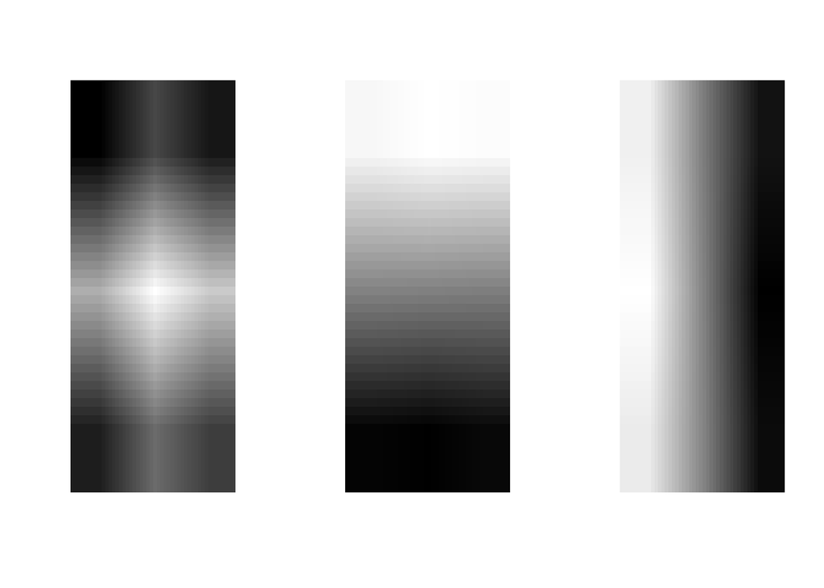

*Figure 19: Component 1,2 and 3 (as 3 by 3 image), respectively on the figure*

After plotting the first 3 components, it can be said that different eigenvectors are identifying different level of intensities. For example the first component differs on the middle on the image while second one’s intensity level is changing in the vertical azis and the third one has different level of intensities in the horizontal axis.

#### APPENDİX: R Codes

```
#install.packages("data.table")
#install.packages("anytime")
require(data.table)
require(anytime)

matches_file_path='C:/Users/AHMET/Desktop/IE 582/Homework 1/IE582Fall2018_project_files/df9b1196-e3cf-4cc7-9159-f236fe738215_matches.rds'
odd_details_file_path='C:/Users/AHMET/Desktop/IE 582/Homework 1/IE582Fall2018_project_files/df9b1196-e3cf-4cc7-9159-f236fe738215_odd_details.rds'

matches=readRDS(matches_file_path)

odds=readRDS(odd_details_file_path)

matches=unique(matches)

#transform unix time to date
matches[,match_date:=anydate(date)]
#transform unix time to date time
matches[,match_time:=anytime(date)]

#order by home team and match date (decreasing)
matches=matches[order(home,-match_time)]

#only one column deletion
matches[,date:=NULL]

matches[,c("HomeGoals","AwayGoals"):=tstrsplit(score,':')]

matches[,Year:=year(match_time)]
matches[,Month:=month(match_time)]
matches[,Weekday:=wday(match_time)]
matches[,Hour:=hour(match_time)]

#transform characters to numeric for scores
matches$HomeGoals=as.numeric(matches$HomeGoals)
matches[,AwayGoals:=as.numeric(AwayGoals)]

#calculate total goals
matches[,TotalGoals:=HomeGoals+AwayGoals]

# mark over under
```

[output cut: 214 more lines]

```
Eigenvector1<-matrix(pca_patches$loadings[,1],3,3) # Part 3.c - First 3 components (eigenvector) of PCA
Eigenvector1<-((Eigenvector1-min(Eigenvector1))/(max(Eigenvector1)-min(Eigenvector1)))
par(mfrow=c(1,3))
plot(0:1,0:1,type="n",main="Component (Eigenvector) 1",axes=FALSE)
rasterImage(Eigenvector1,0,0,1,1)

Eigenvector2<-matrix(pca_patches$loadings[,2],3,3)
Eigenvector2<-((Eigenvector2-min(Eigenvector2))/(max(Eigenvector2)-min(Eigenvector2)))
plot(0:1,0:1,type="n",main="Component (Eigenvector) 2",axes=FALSE)
rasterImage(Eigenvector2,0,0,1,1)

Eigenvector3<-matrix(pca_patches$loadings[,3],3,3)
Eigenvector3<-((Eigenvector3-min(Eigenvector3))/(max(Eigenvector3)-min(Eigenvector3)))
plot(0:1,0:1,type="n",main="Component (Eigenvector) 3",axes=FALSE)
rasterImage(Eigenvector3,0,0,1,1)
```